# HSF Knockdown and Nab-Paclitaxel Effects on PDCL5 Kinome Signaling_STK

#### Z Scores Plot

We will plot the individual and averaged Z scores using both the across and within chip analyses.

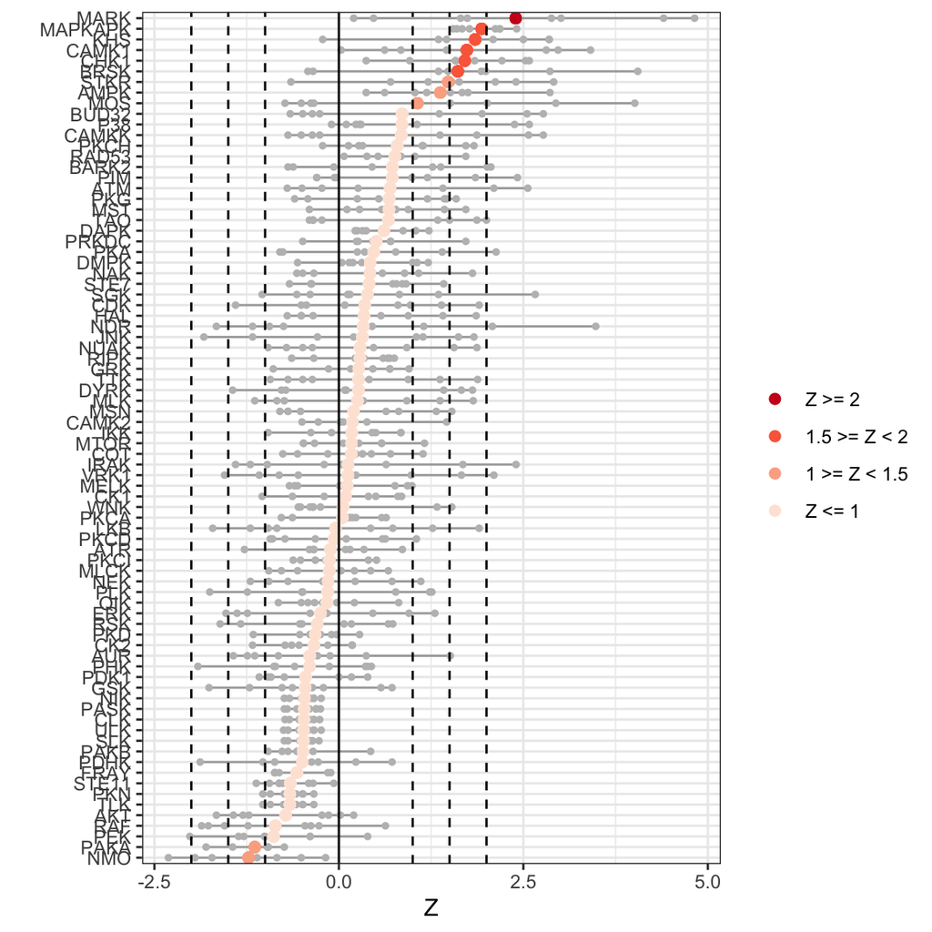

Waterfall plot of the Z Scores of each kinase family

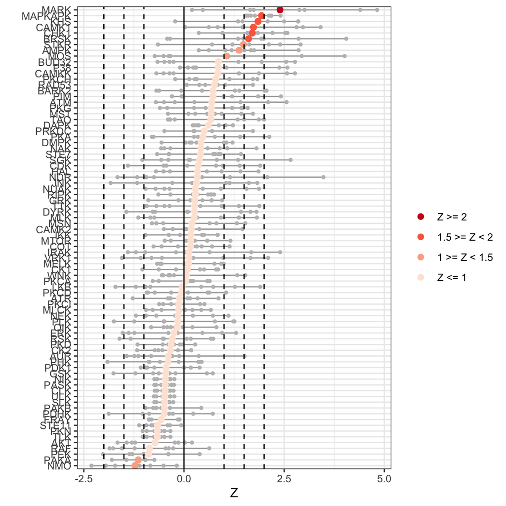

Waterfall plot of the Z Scores of each kinase family

#### Reverse KRSA Plot

We will use the reverse KRSA plot function, to plot the log2 fold change values for all peptides mapped to kinase hits. This will help us examine the activity of the kinase

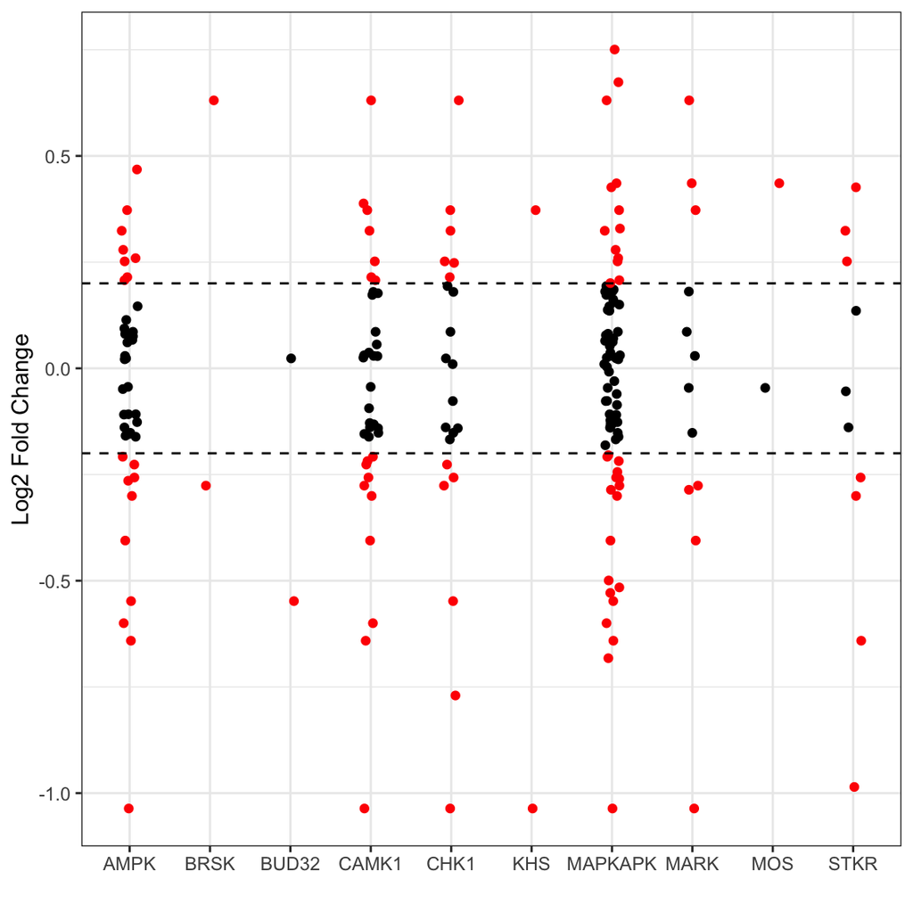

Kinase Activity summary for each kinase family based on peptide phosphorylation

#### Coverage Plot

To view the coverage of kinases across the full list of peptides on the chip, we will use the coverage plot function

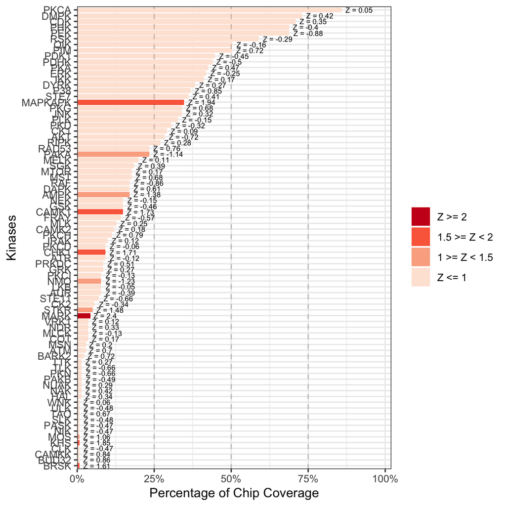

Percentage of peptides each kinase family phosphorylates

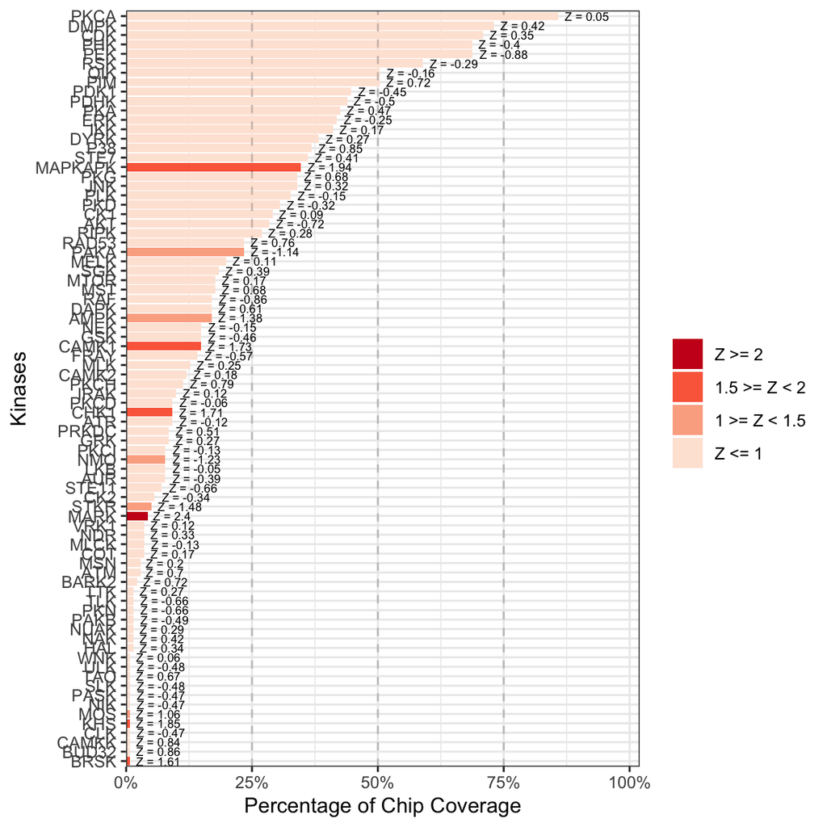

Percentage of peptides each kinase family phosphorylates

#### Ball Model Network

We will view the ball model network function, to generate a model representing the protein-protein interactions between kinases

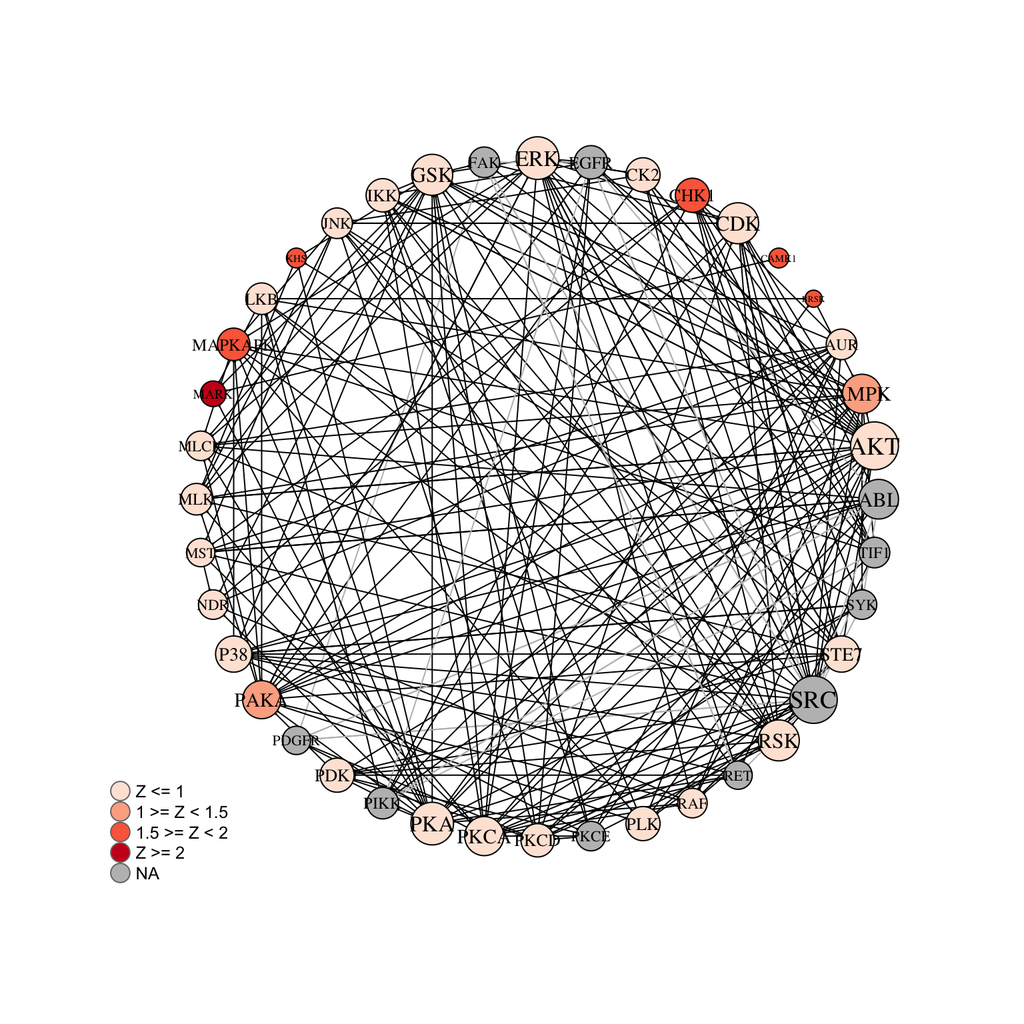

### ShHSFi-NPTX vs ShSr-NPTX

After applying the *Filtering Parameters* for this group comparison, only *44*/141 peptides carried forward in the analysis (i.e. *44 hits*). Below are some figures to visualize the differences between these samples for considering these *hits*.

#### Violin Plot

Below, the violin plot visualizes the distribution of selected peptides for the analysis.

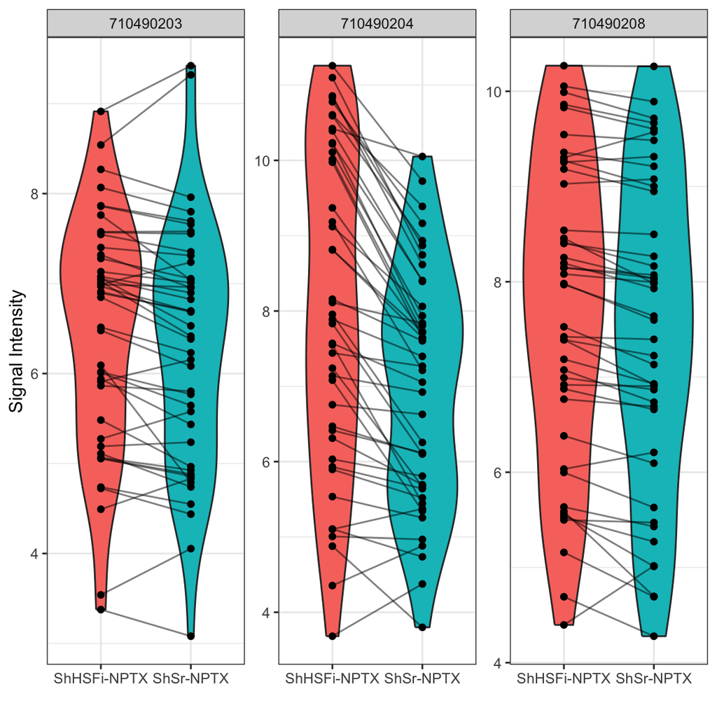

Violin plot of two groups

#### Waterfall Plot

This waterfall represents the log2 fold changes between the two groups at each peptide.

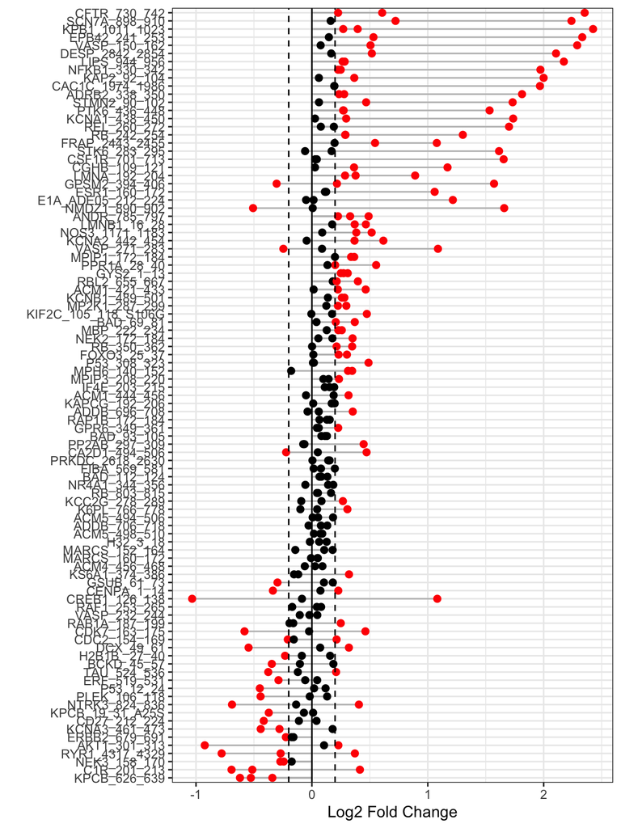

Waterfall Plot to show the distribution of change in peptide phosphorylation

#### Upstream Kinase Analysis

The lab carefully curated and mapped the kinases that can act and phosphorylate each peptide present on the chip. This was achieved by using multiple sources including GPS 3.0, Kinexus Phosphonet, PhosphoELM and PhosphoSite Plus. Based on that association between peptides and kinases, a random sampling analysis is performed for these hits. The basic idea of *KRSA* is: For each iteration (*2000* iterations performed in this analysis), the same number of hits are randomly selected from the total 141/or 193 peptides present on the chip. Predicted kinases are then mapped to this sample list of peptides and number of kinases are determined. The kinase count from the actual hits and random sampling is then compared to determine the significance.

| Kinase | AvgZ |
| --- | --- |
| CAMK1 | 1.4316667 |
| AMPK | 1.2708333 |
| TAO | 1.1708333 |
| MAPKAPK | 0.9000000 |
| RAD53 | 0.8958333 |
| PIM | 0.8875000 |
| RSK | 0.8391667 |
| PKG | 0.7875000 |
| MSN | 0.7841667 |
| PKA | 0.7683333 |
| PDK1 | -0.8050000 |
| PEK | -0.8241667 |
| QIK | -0.8416667 |
| RAF | -0.8433333 |
| CDK | -0.8700000 |
| TLK | -0.8783333 |
| PLK | -1.2500000 |
| JNK | -1.4658333 |
| ERK | -1.6658333 |
| NMO | -1.6683333 |

| Method | NumberOfPeptides |
| --- | --- |
| meanLFC.0.15 | 56 |
| meanLFC.0.2 | 44 |
| meanLFC.0.3 | 32 |
| meanLFC.0.4 | 24 |
| 710490203.0.15 | 65 |
| 710490203.0.2 | 49 |
| 710490203.0.3 | 29 |
| 710490203.0.4 | 17 |
| 710490204.0.15 | 63 |
| 710490204.0.2 | 54 |
| 710490204.0.3 | 41 |
| 710490204.0.4 | 33 |
| 710490208.0.15 | 50 |
| 710490208.0.2 | 38 |
| 710490208.0.3 | 22 |
| 710490208.0.4 | 12 |

#### Z Scores Plot

We will plot the individual and averaged Z scores using both the across and within chip analyses.

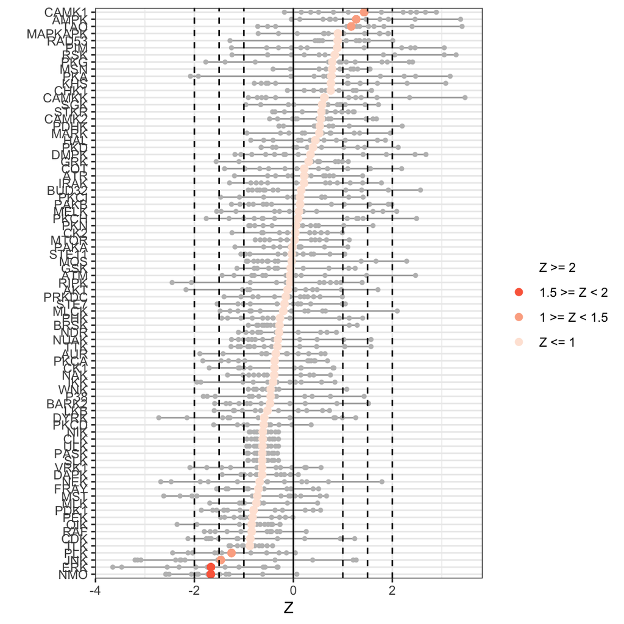

Waterfall plot of the Z Scores of each kinase family

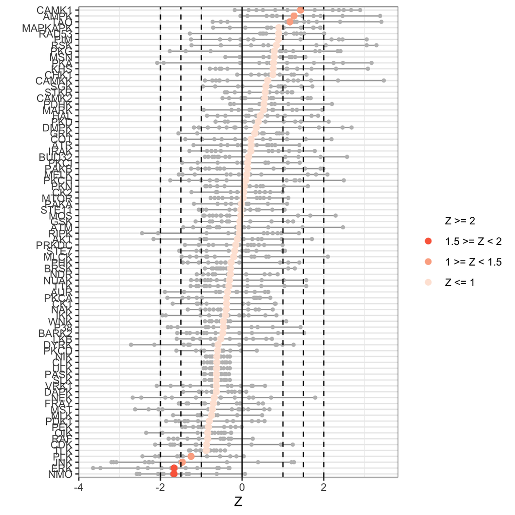

Waterfall plot of the Z Scores of each kinase family

#### Reverse KRSA Plot

We will use the reverse KRSA plot function, to plot the log2 fold change values for all peptides mapped to kinase hits. This will help us examine the activity of the kinase

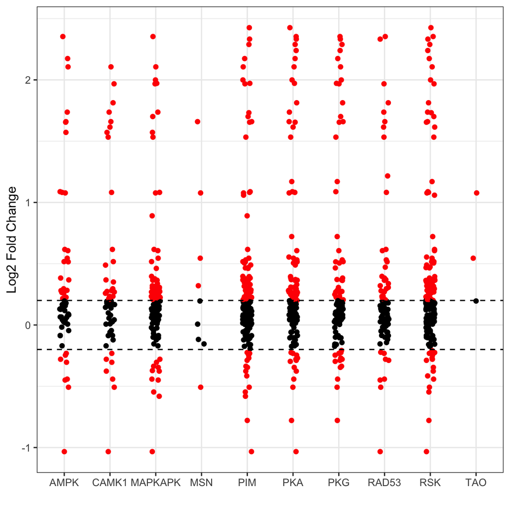

Kinase Activity summary for each kinase family based on peptide phosphorylation

#### Coverage Plot

To view the coverage of kinases across the full list of peptides on the chip, we will use the coverage plot function

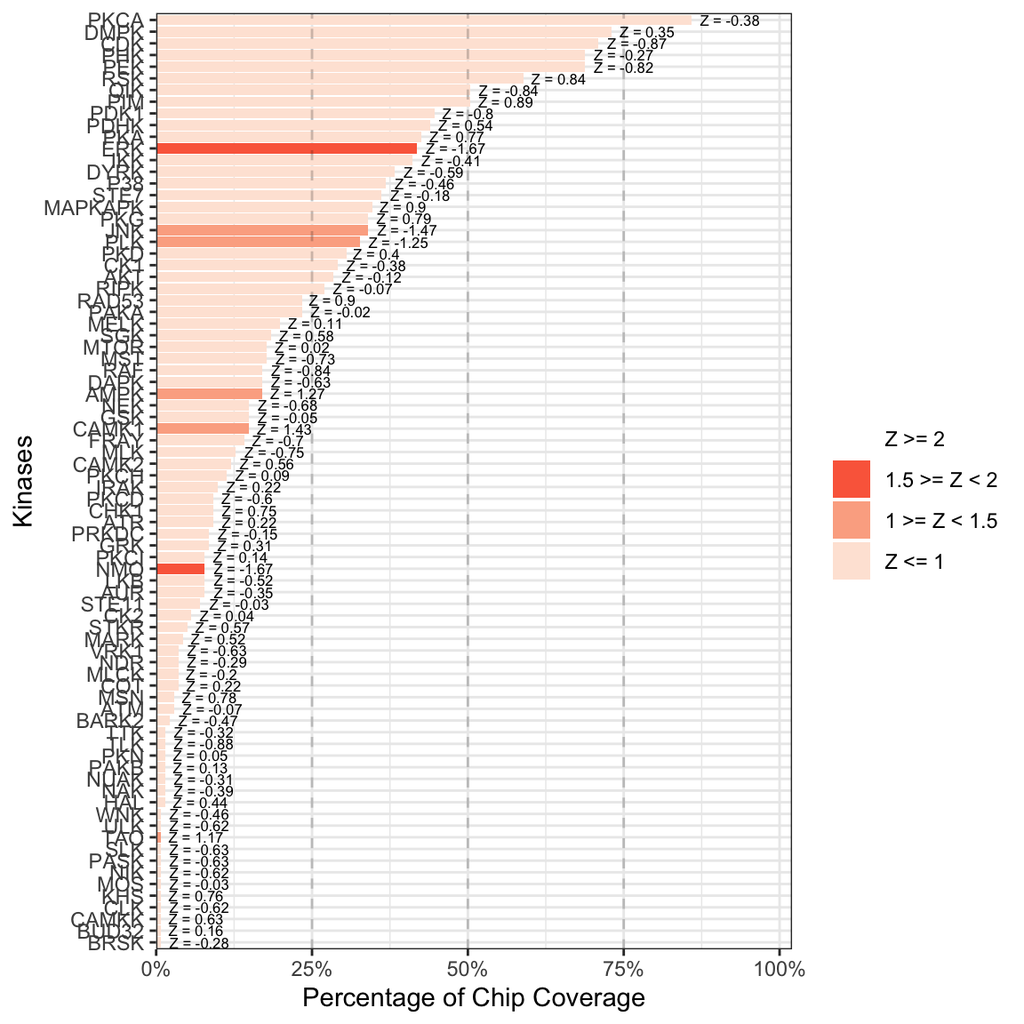

Percentage of peptides each kinase family phosphorylates

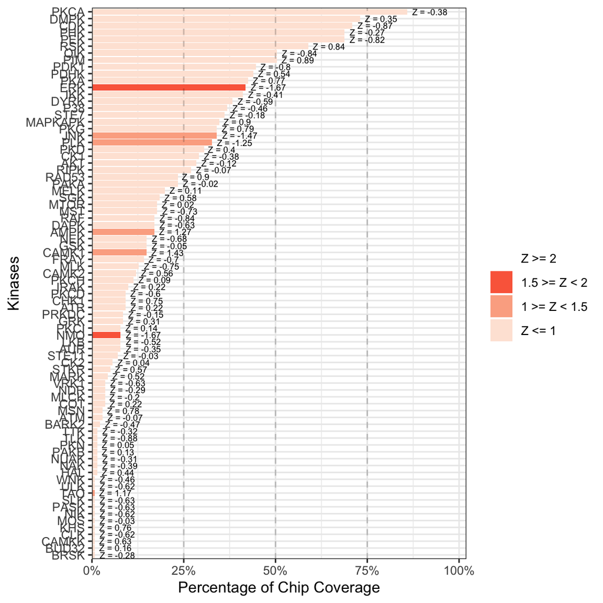

Percentage of peptides each kinase family phosphorylates

#### Ball Model Network

We will view the ball model network function, to generate a model representing the protein-protein interactions between kinases

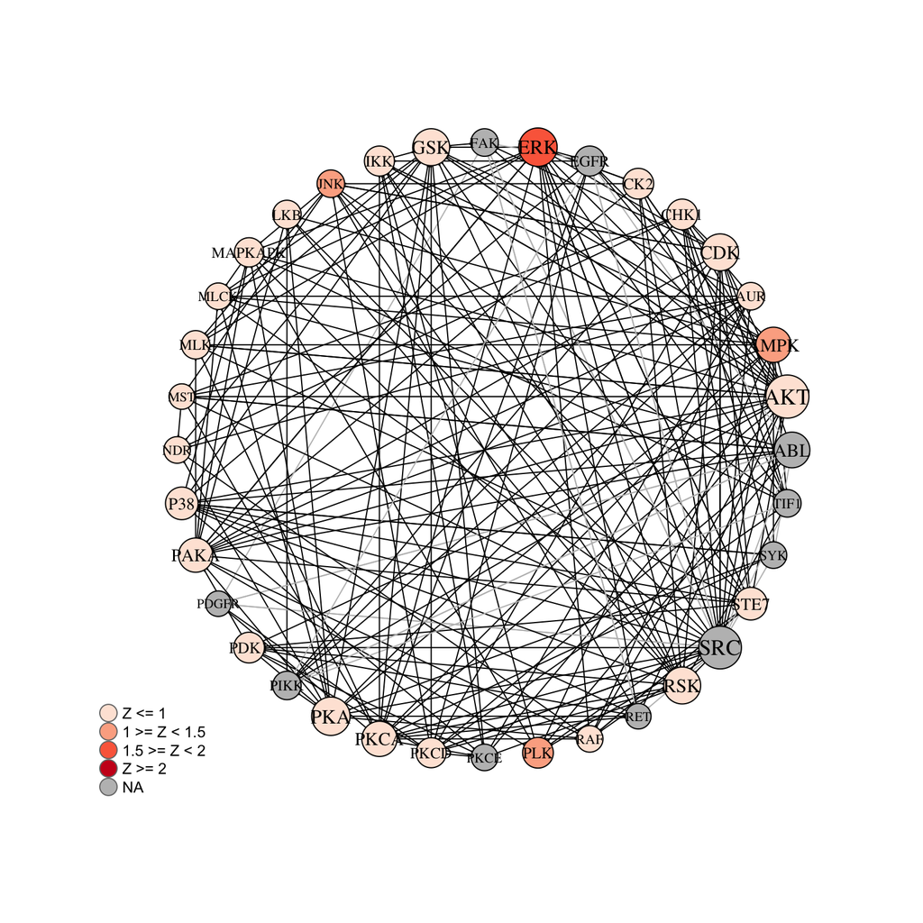